# NYPD Shootings

McNealy, Samantha

2023-12-10

# Analyses of Shooting Incidents in New York City

The data set I will be using was found at https://catalog.data.gov/dataset. According tho the data.gov this data set lists every shooting incident that occurred in NYC from 2006 until its most recent update in 2023.

To find out more information regarding the dataset please visit the website.

## Packages

I will include all packages used here in this section:

```r
library(tidyverse)
library(lubridate)
library(ggplot2)
library(forecast)
```

## Import Data

I will start by importing my data set. For this project we are using the data set titled NYPD Shooting Incident Data (Historic) from https://data.cityofnewyork.us/api/views/833y-fsy8/rows.csv?accessType=DOWNLOAD.

Lets read in the data and see what we have.

```r
shooting_incidents <- read.csv("https://data.cityofnewyork.us/api/views/833y-fsy8/rows.csv?accessType=DOWNLOAD")
```

## Tidy the data

First lets view the data and decide what changes we should make.

```r
head(shooting_incidents)
```

```
##   INCIDENT_KEY OCCUR_DATE OCCUR_TIME     BORO LOC_OF_OCCUR_DESC PRECINCT
## 1    228798151 05/27/2021   21:30:00   QUEENS                        105
## 2    137471050 06/27/2014   17:40:00    BRONX                         40
## 3    147998800 11/21/2015   03:56:00   QUEENS                        108
## 4    146837977 10/09/2015   18:30:00    BRONX                         44
## 5     58921844 02/19/2009   22:58:00    BRONX                         47
## 6    219559682 10/21/2020   21:36:00 BROOKLYN                         81
##   JURISDICTION_CODE LOC_CLASSFCTN_DESC LOCATION_DESC STATISTICAL_MURDER_FLAG
## 1                 0                                                    false
## 2                 0                                                    false
## 3                 0                                                     true
## 4                 0                                                    false
## 5                 0                                                     true
## 6                 0                                                     true
##   PERP_AGE_GROUP PERP_SEX PERP_RACE VIC_AGE_GROUP VIC_SEX       VIC_RACE
```

[output cut: 20 more lines]

```r
summary(shooting_incidents)
```

```
##   INCIDENT_KEY        OCCUR_DATE         OCCUR_TIME            BORO
##  Min.   :  9953245   Length:27312       Length:27312       Length:27312
##  1st Qu.: 63860880   Class :character   Class :character   Class :character
##  Median : 90372218   Mode  :character   Mode  :character   Mode  :character
##  Mean   :120860536
##  3rd Qu.:188810230
##  Max.   :261190187
##
##  LOC_OF_OCCUR_DESC     PRECINCT      JURISDICTION_CODE LOC_CLASSFCTN_DESC
##  Length:27312       Min.   :  1.00   Min.   :0.0000    Length:27312
##  Class :character   1st Qu.: 44.00   1st Qu.:0.0000    Class :character
##  Mode  :character   Median : 68.00   Median :0.0000    Mode  :character
##                     Mean   : 65.64   Mean   :0.3269
##                     3rd Qu.: 81.00   3rd Qu.:0.0000
##                     Max.   :123.00   Max.   :2.0000
##                                      NA's   :2
##  LOCATION_DESC      STATISTICAL_MURDER_FLAG PERP_AGE_GROUP
##  Length:27312       Length:27312            Length:27312
##  Class :character   Class :character        Class :character
##  Mode  :character   Mode  :character        Mode  :character
##
##
##
##
##    PERP_SEX          PERP_RACE         VIC_AGE_GROUP        VIC_SEX
##  Length:27312       Length:27312       Length:27312       Length:27312
##  Class :character   Class :character   Class :character   Class :character
##  Mode  :character   Mode  :character   Mode  :character   Mode  :character
##
##
##
##
##    VIC_RACE           X_COORD_CD        Y_COORD_CD        Latitude
##  Length:27312       Min.   : 914928   Min.   :125757   Min.   :40.51
##  Class :character   1st Qu.:1000028   1st Qu.:182834   1st Qu.:40.67
##  Mode  :character   Median :1007731   Median :194487   Median :40.70
##                     Mean   :1009449   Mean   :208127   Mean   :40.74
##                     3rd Qu.:1016838   3rd Qu.:239518   3rd Qu.:40.82
##                     Max.   :1066815   Max.   :271128   Max.   :40.91
##                                                        NA's   :10
##    Longitude        Lon_Lat
##  Min.   :-74.25   Length:27312
##  1st Qu.:-73.94   Class :character
##  Median :-73.92   Mode  :character
##  Mean   :-73.91
##  3rd Qu.:-73.88
##  Max.   :-73.70
##  NA's   :10
```

After viewing I have decided to remove some columns that I will not be using, change the format of the columns, change the name of some of the columns, and deal with the missing data.

#### 1. Deleting columns

There are currently 21 columns. I have decided to remove 11 columns: INCIDENT_KEY, LOC_OF_OCCUR_DESC, JURISDICTION_CODE, PRECINCT, LOC_CLASSFCTN_DESC, LOCATION_DESC, X_COORD_CD, Y_COORD_CD, Latitude, Longitude, and Lon_Lat.

```r
colnames(shooting_incidents)
```

```
##  [1] "INCIDENT_KEY"            "OCCUR_DATE"
##  [3] "OCCUR_TIME"              "BORO"
##  [5] "LOC_OF_OCCUR_DESC"       "PRECINCT"
##  [7] "JURISDICTION_CODE"       "LOC_CLASSFCTN_DESC"
##  [9] "LOCATION_DESC"           "STATISTICAL_MURDER_FLAG"
## [11] "PERP_AGE_GROUP"          "PERP_SEX"
## [13] "PERP_RACE"               "VIC_AGE_GROUP"
## [15] "VIC_SEX"                 "VIC_RACE"
## [17] "X_COORD_CD"              "Y_COORD_CD"
## [19] "Latitude"                "Longitude"
## [21] "Lon_Lat"
```

```r
shooting_incidents <- shooting_incidents %>% select(-INCIDENT_KEY, -LOC_OF_OCCUR_DESC, -JURISDICTION_CODE, -PRECINCT, -LOC_CLASSFCTN_DESC, -PRECINCT, -LOCATION_DESC, -X_COORD_CD, -Y_COORD_CD, -Latitude, -Longitude, -Lon_Lat)

head(shooting_incidents)
```

```
##   OCCUR_DATE OCCUR_TIME     BORO STATISTICAL_MURDER_FLAG PERP_AGE_GROUP
## 1 05/27/2021   21:30:00   QUEENS                   false
## 2 06/27/2014   17:40:00    BRONX                   false
## 3 11/21/2015   03:56:00   QUEENS                    true
## 4 10/09/2015   18:30:00    BRONX                   false
## 5 02/19/2009   22:58:00    BRONX                    true          25-44
## 6 10/21/2020   21:36:00 BROOKLYN                    true
##   PERP_SEX PERP_RACE VIC_AGE_GROUP VIC_SEX       VIC_RACE
## 1                            18-24       M          BLACK
## 2                            18-24       M          BLACK
## 3                            25-44       M          WHITE
## 4                              <18       M WHITE HISPANIC
## 5        M     BLACK         45-64       M          BLACK
## 6                            25-44       M          BLACK
```

#### 2. Date & Time

The column “OCCUR_DATE” is currently read as a character. In order to perform date specific operations I will change the class to make it into a date. I will also rename this column “date”.

```r
shooting_incidents$OCCUR_DATE <- mdy(shooting_incidents$OCCUR_DATE)

names(shooting_incidents)[names(shooting_incidents) == "OCCUR_DATE"] <- "date"

summary(shooting_incidents)
```

```
##       date             OCCUR_TIME            BORO
##  Min.   :2006-01-01   Length:27312       Length:27312
##  1st Qu.:2009-07-18   Class :character   Class :character
##  Median :2013-04-29   Mode  :character   Mode  :character
##  Mean   :2014-01-06
##  3rd Qu.:2018-10-15
##  Max.   :2022-12-31
##  STATISTICAL_MURDER_FLAG PERP_AGE_GROUP       PERP_SEX
##  Length:27312            Length:27312       Length:27312
##  Class :character        Class :character   Class :character
##  Mode  :character        Mode  :character   Mode  :character
##
##
##
##   PERP_RACE         VIC_AGE_GROUP        VIC_SEX            VIC_RACE
##  Length:27312       Length:27312       Length:27312       Length:27312
##  Class :character   Class :character   Class :character   Class :character
##  Mode  :character   Mode  :character   Mode  :character   Mode  :character
##
##
##
```

The column “OCCUR_TIME” is currently read as a character. It is currently in 2 different formats so I have decided to combine the date and time into one column called “datetime”.

```r
shooting_incidents <- shooting_incidents %>%
     mutate(datetime = ymd(date) + hms(OCCUR_TIME))
```

Using the datetime that I just created I will create additional columns. Month, Day, and Year.

```r
shooting_incidents <- shooting_incidents %>%
  mutate(Year = year(datetime), Month = month(datetime), Day = day(datetime))
```

Next I will create additional columns weekday and weeknumber and view the changes made.

```r
shooting_incidents <- shooting_incidents %>%
  mutate(Weekday = wday(datetime, label = TRUE), WeekNumber = week(datetime))

head(shooting_incidents)
```

```
##         date OCCUR_TIME     BORO STATISTICAL_MURDER_FLAG PERP_AGE_GROUP
## 1 2021-05-27   21:30:00   QUEENS                   false
## 2 2014-06-27   17:40:00    BRONX                   false
## 3 2015-11-21   03:56:00   QUEENS                    true
## 4 2015-10-09   18:30:00    BRONX                   false
## 5 2009-02-19   22:58:00    BRONX                    true          25-44
## 6 2020-10-21   21:36:00 BROOKLYN                    true
##   PERP_SEX PERP_RACE VIC_AGE_GROUP VIC_SEX       VIC_RACE            datetime
## 1                            18-24       M          BLACK 2021-05-27 21:30:00
## 2                            18-24       M          BLACK 2014-06-27 17:40:00
## 3                            25-44       M          WHITE 2015-11-21 03:56:00
## 4                              <18       M WHITE HISPANIC 2015-10-09 18:30:00
## 5        M     BLACK         45-64       M          BLACK 2009-02-19 22:58:00
## 6                            25-44       M          BLACK 2020-10-21 21:36:00
##   Year Month Day Weekday WeekNumber
## 1 2021     5  27     Thu         21
## 2 2014     6  27     Fri         26
## 3 2015    11  21     Sat         47
## 4 2015    10   9     Fri         41
## 5 2009     2  19     Thu          8
## 6 2020    10  21     Wed         43
```

#### 3. Missing data

As you saw when we viewed the data, there is currently data that is empty or missing. First let see how much data is missing and them decide what to do with it.

```r
character_columns <- sapply(shooting_incidents, is.character)

missing_counts <- shooting_incidents %>%
  select(which(character_columns)) %>%
  summarise_all(~sum(is.na(.) | . == ""))

print(missing_counts)
```

```
##   OCCUR_TIME BORO STATISTICAL_MURDER_FLAG PERP_AGE_GROUP PERP_SEX PERP_RACE
## 1          0    0                       0           9344     9310      9310
##   VIC_AGE_GROUP VIC_SEX VIC_RACE
## 1             0       0        0
```

As you see here the perpetrator data age group, sex, and race are missing a high rate of data. This is probably still an onging case. Because of this I have decided to remove these three columns of data.

```r
shooting_incidents <- shooting_incidents %>%
  select(-PERP_AGE_GROUP, -PERP_SEX, -PERP_RACE)

head(shooting_incidents)
```

```
##         date OCCUR_TIME     BORO STATISTICAL_MURDER_FLAG VIC_AGE_GROUP VIC_SEX
## 1 2021-05-27   21:30:00   QUEENS                   false         18-24       M
## 2 2014-06-27   17:40:00    BRONX                   false         18-24       M
## 3 2015-11-21   03:56:00   QUEENS                    true         25-44       M
## 4 2015-10-09   18:30:00    BRONX                   false           <18       M
## 5 2009-02-19   22:58:00    BRONX                    true         45-64       M
## 6 2020-10-21   21:36:00 BROOKLYN                    true         25-44       M
##         VIC_RACE            datetime Year Month Day Weekday WeekNumber
## 1          BLACK 2021-05-27 21:30:00 2021     5  27     Thu         21
## 2          BLACK 2014-06-27 17:40:00 2014     6  27     Fri         26
## 3          WHITE 2015-11-21 03:56:00 2015    11  21     Sat         47
## 4 WHITE HISPANIC 2015-10-09 18:30:00 2015    10   9     Fri         41
## 5          BLACK 2009-02-19 22:58:00 2009     2  19     Thu          8
## 6          BLACK 2020-10-21 21:36:00 2020    10  21     Wed         43
```

#### 4. Rename Columns

Next I will to is rename some columns to make the names more consistent.

```r
shooting_incidents <- shooting_incidents %>%
  rename(boro = BORO, death = STATISTICAL_MURDER_FLAG, vic_age_group = VIC_AGE_GROUP, vic_sex = VIC_SEX, vic_race= VIC_RACE, Time = OCCUR_TIME)

colnames(shooting_incidents)
```

```
##  [1] "date"          "Time"          "boro"          "death"
##  [5] "vic_age_group" "vic_sex"       "vic_race"      "datetime"
##  [9] "Year"          "Month"         "Day"           "Weekday"
## [13] "WeekNumber"
```

#### 5. View data and modify

Currently we have reduced our data set down to 13 columns. Now we will view some information in each of the columns to check for inconsistent data.

```r
value_counts1 <- table(shooting_incidents$vic_race)
value_counts1
```

```
##
## AMERICAN INDIAN/ALASKAN NATIVE       ASIAN / PACIFIC ISLANDER
##                             10                            404
##                          BLACK                 BLACK HISPANIC
##                          19439                           2646
##                        UNKNOWN                          WHITE
##                             66                            698
##                 WHITE HISPANIC
##                           4049
```

```r
value_counts2 <- table(shooting_incidents$vic_age_group)
value_counts2
```

```
##
##     <18    1022   18-24   25-44   45-64     65+ UNKNOWN
##    2839       1   10086   12281    1863     181      61
```

```r
value_counts3 <- table(shooting_incidents$vic_sex)
value_counts3
```

```
##
##     F     M     U
##  2615 24686    11
```

```r
value_counts4 <- table(shooting_incidents$boro)
value_counts4
```

```
##
##         BRONX      BROOKLYN     MANHATTAN        QUEENS STATEN ISLAND
##          7937         10933          3572          4094           776
```

```r
value_counts5 <- table(shooting_incidents$death)
value_counts5
```

```
##
## false  true
## 22046  5266
```

```r
value_counts6 <- table(shooting_incidents$Year)
value_counts6
```

```
##
## 2006 2007 2008 2009 2010 2011 2012 2013 2014 2015 2016 2017 2018 2019 2020 2021
## 2055 1887 1959 1828 1912 1939 1717 1339 1464 1434 1208  970  958  967 1948 2011
## 2022
## 1716
```

```r
value_counts7 <- table(shooting_incidents$Month)
value_counts7
```

```
##
##    1    2    3    4    5    6    7    8    9   10   11   12
## 1716 1340 1688 1983 2571 2829 3238 3156 2572 2279 1944 1996
```

```r
value_counts8 <- table(shooting_incidents$Day)
value_counts8
```

```
##
##    1    2    3    4    5    6    7    8    9   10   11   12   13   14   15   16
##  951  927  818  914 1029  849  851  808  866  786  903  882  870  826  865  871
##   17   18   19   20   21   22   23   24   25   26   27   28   29   30   31
##  897  884  859  873  945  940  911  842  936  954  983  890  850  863  669
```

```r
value_counts9 <- table(shooting_incidents$WeekNumber)
value_counts9
```

```
##
##   1   2   3   4   5   6   7   8   9  10  11  12  13  14  15  16  17  18  19  20
## 489 387 350 339 349 340 303 323 322 367 404 439 377 415 469 459 522 483 471 587
##  21  22  23  24  25  26  27  28  29  30  31  32  33  34  35  36  37  38  39  40
## 661 670 575 587 752 747 890 683 696 664 712 713 694 701 768 703 491 561 596 549
##  41  42  43  44  45  46  47  48  49  50  51  52  53
## 502 510 492 497 418 491 487 414 442 427 441 480 103
```

```r
value_counts10 <- table(shooting_incidents$Weekday)
value_counts10
```

```
##
##  Sun  Mon  Tue  Wed  Thu  Fri  Sat
## 5452 3883 3163 3000 3034 3585 5195
```

When looking at this data I have found one data entry error on the vic_age_group column. One age range is listed as ‘1022’. I don’t want this to interfere with the data when comparing different age groups so I will change this value to ‘UNKNOWN’. I will then confirm that the change has been made. Another thing worth to noting is that there are 11 shooting incidents where the victim sex is unknown. This could be due to data recording issues or these individuals do not fit into traditional male/female classification. For this reason I have decided to keep this data.

```r
row_to_change <- which(shooting_incidents$vic_age_group == "1022")

shooting_incidents$vic_age_group[row_to_change] <- "UNKNOWN"

value_counts <- table(shooting_incidents$vic_age_group)
value_counts
```

```
##
##     <18   18-24   25-44   45-64     65+ UNKNOWN
##    2839   10086   12281    1863     181      62
```

#### 6. Data types

Currently the victim age group, race, and sex data type is ‘character’. I will convert these to ‘factor’ as they contain a limited number of repeating categories. this conversion may enhance performance and usage.

```r
shooting_incidents$vic_age_group <- as.factor(shooting_incidents$vic_age_group)

shooting_incidents$vic_sex <- as.factor(shooting_incidents$vic_sex)

shooting_incidents$vic_race <- as.factor(shooting_incidents$vic_race)

column_classes <- sapply(shooting_incidents, class)

print(column_classes)
```

```
## $date
## [1] "Date"
##
## $Time
## [1] "character"
##
## $boro
## [1] "character"
##
## $death
## [1] "character"
##
## $vic_age_group
## [1] "factor"
##
## $vic_sex
## [1] "factor"
##
## $vic_race
## [1] "factor"
##
## $datetime
## [1] "POSIXct" "POSIXt"
##
## $Year
## [1] "numeric"
##
## $Month
## [1] "numeric"
##
## $Day
## [1] "integer"
##
## $Weekday
## [1] "ordered" "factor"
##
## $WeekNumber
## [1] "numeric"
```

The death column is currently formatted as ‘character’. Because this contains binary values of true and false, we will convert it to a ‘logical’ type.

```r
shooting_incidents$death <- tolower(shooting_incidents$death) == "true"

column_classes <- sapply(shooting_incidents, class)

print(column_classes)
```

```
## $date
## [1] "Date"
##
## $Time
## [1] "character"
##
## $boro
## [1] "character"
##
## $death
## [1] "logical"
##
## $vic_age_group
## [1] "factor"
##
## $vic_sex
## [1] "factor"
##
## $vic_race
## [1] "factor"
##
## $datetime
## [1] "POSIXct" "POSIXt"
##
## $Year
## [1] "numeric"
##
## $Month
## [1] "numeric"
##
## $Day
## [1] "integer"
##
## $Weekday
## [1] "ordered" "factor"
##
## $WeekNumber
## [1] "numeric"
```

## Add Visualizations and Analysis

#### 1. What are the proportion of shooting incidents that result in death?

To find the proportion of shooting incidents that result in a death I will calculate the death proportion, create a new data frame for our death proportion in order to plot, and then plot this onto a graph.

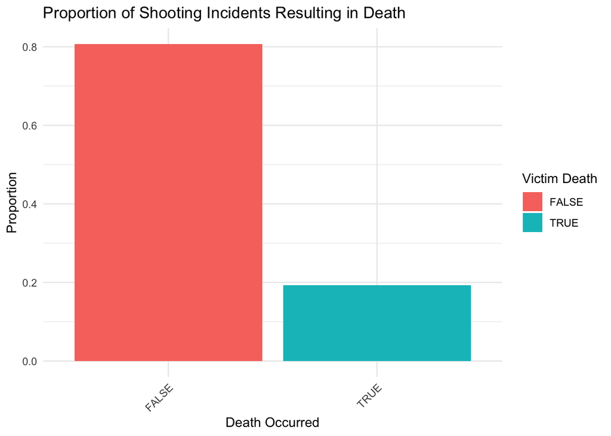

```r
death_proportion <- table(shooting_incidents$death) / nrow(shooting_incidents)

death_df <- as.data.frame(death_proportion)

ggplot(death_df, aes(x = Var1, y = Freq, fill = Var1)) +
  geom_bar(stat = "identity") +
  ggtitle("Proportion of Shooting Incidents Resulting in Death") +
  xlab("Death Occurred") +
  ylab("Proportion") +
  labs(fill = "Victim Death") +
  theme_minimal() +
  theme(axis.text.x = element_text(angle = 45, hjust = 1))
```

The graph shows that when a shooting incident occurs in one of these boroughs of New York that there is approximately a 20% chance of it ending in death.

#### 2. Are certain boroughs more prone to shooting incidents or fatalities than others?

In the results I will include a graph with the total number of shooting incidents and deaths within each borough. To do this first I will aggregate the data to count the total number of incidents and deaths in each borough. Then I will reshape the data in order for it to be plotted. Finally I will create a graph that shows both totals side by side for each category.

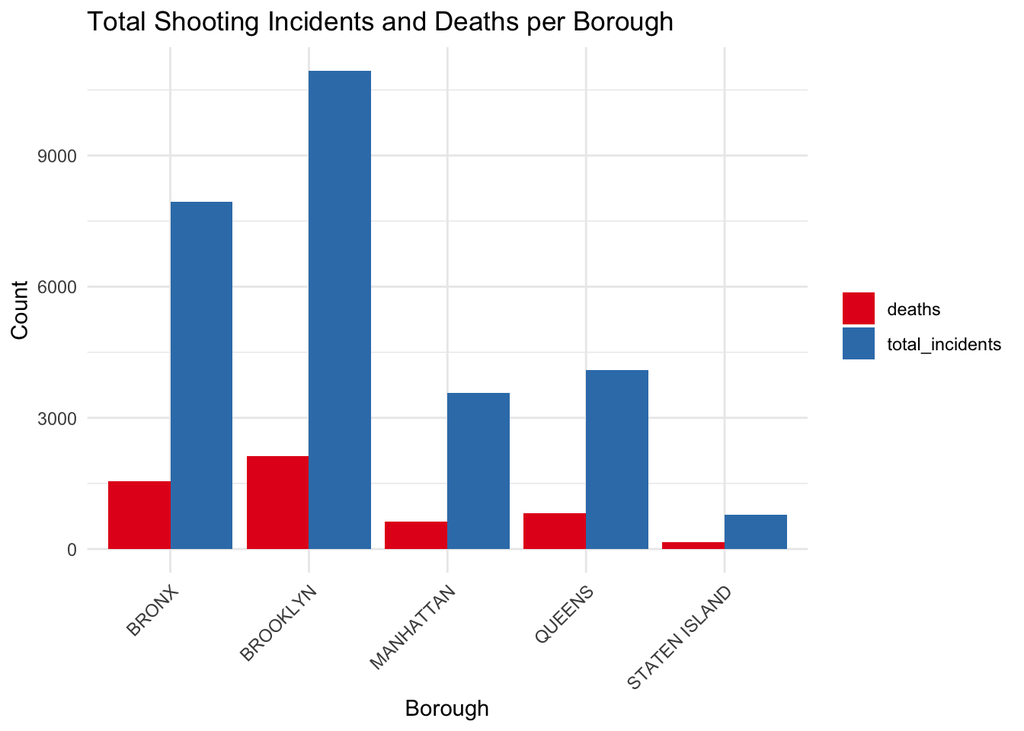

```r
aggregate_data <- shooting_incidents %>%
  group_by(boro) %>%
  summarize(total_incidents = n(),
            deaths = sum(death, na.rm = TRUE))

long_data <- pivot_longer(aggregate_data, cols = c(total_incidents, deaths), names_to = "Metric")

ggplot(long_data, aes(x = boro, y = value, fill = Metric)) +
  geom_bar(stat = "identity", position = position_dodge()) +
  ggtitle("Total Shooting Incidents and Deaths per Borough") +
  xlab("Borough") +
  ylab("Count") +
  labs(fill = "") +
  scale_fill_brewer(palette = "Set1") +
  theme_minimal() +
  theme(axis.text.x = element_text(angle = 45, hjust = 1))
```

Looking at the results of this graph we can conclude that shooting incidents are more likely to occur in the Bronx and Brooklyn and less likely to occur in Staten island, followed by Manhattan, and then Queens.

#### 3. Do victim demographics influence the likelihood of fatal outcomes in shooting incidents?

In order to answer this question we will have to conduct an analysis for each demographic category. I will begin with an analysis by age group.

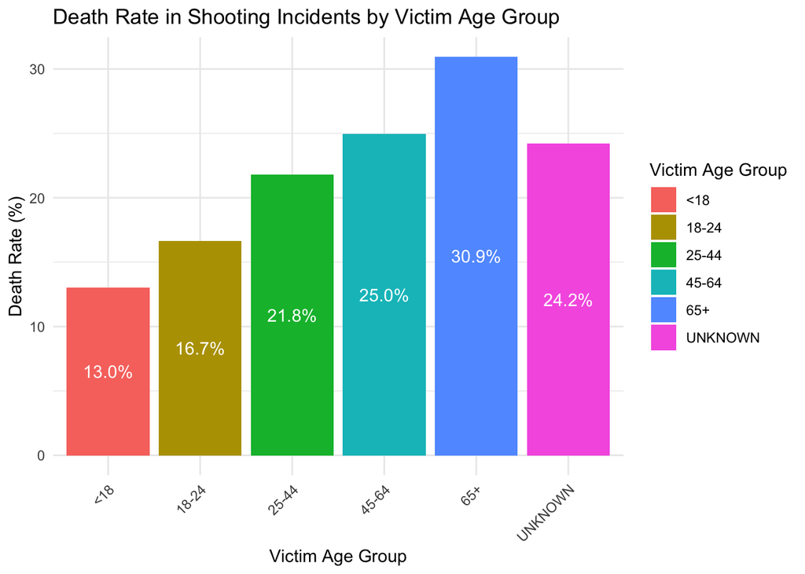

```r
age_group_analysis <- shooting_incidents %>%
  group_by(vic_age_group) %>%
  summarize(total_incidents = n(),
            deaths = sum(death, na.rm = TRUE),
            death_rate = deaths / total_incidents * 100)

ggplot(age_group_analysis, aes(x = vic_age_group, y = death_rate, fill = vic_age_group)) +
  geom_bar(stat = "identity") +
  geom_text(aes(label = paste0(sprintf("%.1f", death_rate), "%")),
            position = position_stack(vjust = 0.5), color = "white") +
  ggtitle("Death Rate in Shooting Incidents by Victim Age Group") +
  xlab("Victim Age Group") +
  ylab("Death Rate (%)") +
  labs(fill = "Victim Age Group") +
  theme_minimal() +
  theme(axis.text.x = element_text(angle = 45, hjust = 1))
```

In this graph we see how likely a victim is to die based on their age. Results show that the older the victim is the more likely they are to die from a shooting incident.

Now lets conduct an analysis by victims sex.

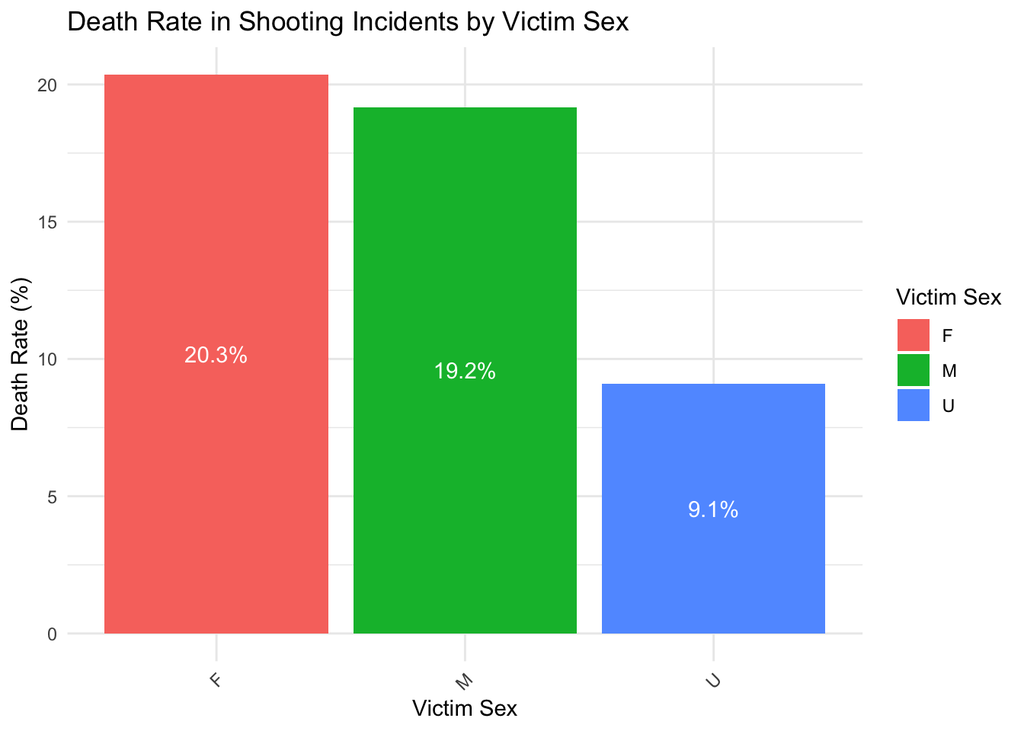

```r
sex_analysis <- shooting_incidents %>%
  group_by(vic_sex) %>%
  summarize(total_incidents = n(),
            deaths = sum(death, na.rm = TRUE),
            death_rate = deaths / total_incidents * 100)

ggplot(sex_analysis, aes(x = vic_sex, y = death_rate, fill = vic_sex)) +
  geom_bar(stat = "identity") +
  geom_text(aes(label = paste0(sprintf("%.1f", death_rate), "%")),
            position = position_stack(vjust = 0.5), color = "white") +
  ggtitle("Death Rate in Shooting Incidents by Victim Sex") +
  xlab("Victim Sex") +
  ylab("Death Rate (%)") +
  labs(fill = "Victim Sex") +
  theme_minimal() +
  theme(axis.text.x = element_text(angle = 45, hjust = 1))
```

In this graph we can see that female death rate in a shooting incident is 20.3% and male death rate in a shooting incident is 19.2% This could indicate that males may be involved in more shooting incidents, the incidents involving females are more likely to be fatal. I would like to note that there is a unknown victim sex column. As mentioned previously only 11 victims of shooting incidents were denoted as unknown. On our current graph we see that the death rate in a shooting incident for those individuals is 9.1%

Now lets conduct an analysis by victims race.

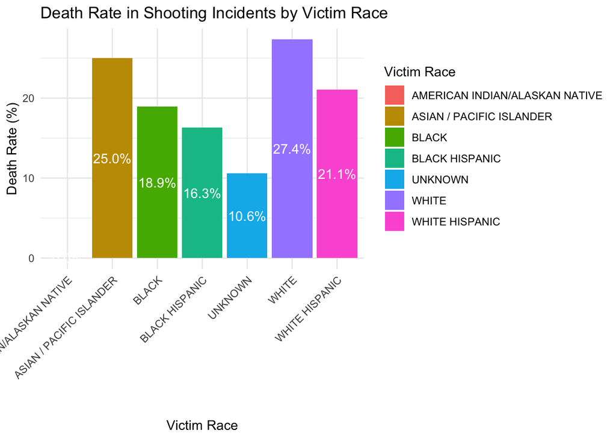

```r
race_analysis <- shooting_incidents %>%
  group_by(vic_race) %>%
  summarize(total_incidents = n(),
            deaths = sum(death, na.rm = TRUE),
            death_rate = deaths / total_incidents * 100)

ggplot(race_analysis, aes(x = vic_race, y = death_rate, fill = vic_race)) +
  geom_bar(stat = "identity") +
  geom_text(aes(label = paste0(sprintf("%.1f", death_rate), "%")),
            position = position_stack(vjust = 0.5), color = "white") +
  ggtitle("Death Rate in Shooting Incidents by Victim Race") +
  xlab("Victim Race") +
  ylab("Death Rate (%)") +
  labs(fill = "Victim Race") +
  theme_minimal() +
  theme(axis.text.x = element_text(angle = 45, hjust = 1))
```

In this graph we can see that the death rate in shooting incidents for victims with the race of White is 27.4% and Asian/Pacific Islander is 25% are the highest. While the death rate in shooting incidents for victims with the race of American Indian/Alaskan native and unknown are the lowest. This leads to the next question.

#### 4. Are the differences in victim race and death rates statistically significant?

To answer this questions we will need to create a contingency table to count the number of deaths. and survivals for each race. Then we will perform a chi-squared test.

```r
death_counts_by_race <- table(shooting_incidents$vic_race, shooting_incidents$death)

chi_squared_test <- chisq.test(death_counts_by_race)
print(chi_squared_test)
```

```
##
##  Pearson's Chi-squared test
##
## data:  death_counts_by_race
## X-squared = 67.951, df = 6, p-value = 1.075e-12
```

#### 5. Are there other variables that could influence the likelihood of a fatal outcome?

We will look at victim race, age group, and sex to see the relationship between the victims demographics and the likelihood of fatal outcomes in shooting incidents. The death column is currently a logical type of data so we will change this to be binary (1/0) instead of (TRUE/FALSE). Then we can run the regression and interpret our results.

```r
shooting_incidents$death <- as.numeric(shooting_incidents$death)

model = glm(death ~ vic_age_group + vic_sex + vic_race, family = "binomial", data = shooting_incidents)

summary(model)
```

```
##
## Call:
## glm(formula = death ~ vic_age_group + vic_sex + vic_race, family = "binomial",
##     data = shooting_incidents)
##
## Coefficients:
##                                   Estimate Std. Error z value Pr(>|z|)
## (Intercept)                      -12.86405  102.16036  -0.126  0.89980
## vic_age_group18-24                 0.28557    0.06197   4.608 4.06e-06 ***
## vic_age_group25-44                 0.61258    0.06005  10.200  < 2e-16 ***
## vic_age_group45-64                 0.75933    0.07781   9.759  < 2e-16 ***
## vic_age_group65+                   1.01911    0.17146   5.944 2.79e-09 ***
## vic_age_groupUNKNOWN               0.85023    0.31531   2.696  0.00701 **
## vic_sexM                          -0.04778    0.05206  -0.918  0.35869
## vic_sexU                          -0.58211    1.08249  -0.538  0.59075
## vic_raceASIAN / PACIFIC ISLANDER  11.28121  102.16041   0.110  0.91207
## vic_raceBLACK                     11.00307  102.16034   0.108  0.91423
## vic_raceBLACK HISPANIC            10.82209  102.16035   0.106  0.91564
## vic_raceUNKNOWN                   10.26523  102.16120   0.100  0.91996
## vic_raceWHITE                     11.34289  102.16038   0.111  0.91159
## vic_raceWHITE HISPANIC            11.12441  102.16035   0.109  0.91329
## ---
## Signif. codes:  0 '***' 0.001 '**' 0.01 '*' 0.05 '.' 0.1 ' ' 1
##
## (Dispersion parameter for binomial family taken to be 1)
##
##     Null deviance: 26781  on 27311  degrees of freedom
## Residual deviance: 26504  on 27298  degrees of freedom
## AIC: 26532
##
## Number of Fisher Scoring iterations: 11
```

Interpretations of the results:

- **Race**: The racial categories do not have p-values below 0.05, suggesting that within this model, race is not a significant predictor of death in shooting incidents.
- **Age Group**: All age groups are statistically significant predictors of death from a shooting incident. As age increases there is a higher likelihood of death during a shooting incidence.
- **Sex**: The sex categories do not appear to be significant predictors in this model.

#### 6. How has the number of deaths changed over time?

Lets check out how the number of deaths has changed over time. First we have to aggregate the data to get number of deaths per year. We will call this yearly_deaths. We can do this by using death and Year columns. Using this we are able to create a graph showing the yearly trend.

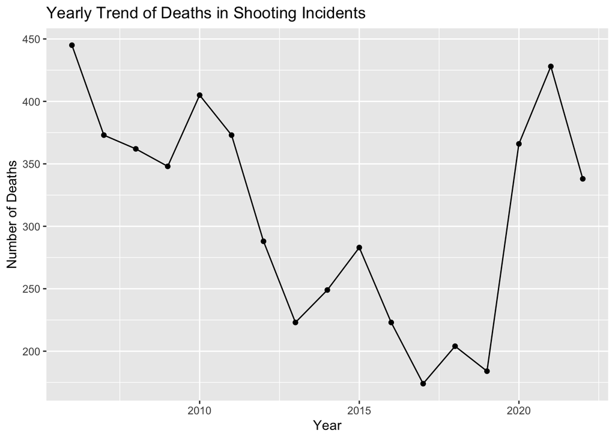

```r
yearly_deaths <- aggregate(death ~ Year, data = shooting_incidents, sum)

ggplot(yearly_deaths, aes(x = Year, y = death)) +
  geom_line() +
  geom_point() +
  ggtitle("Yearly Trend of Deaths in Shooting Incidents") +
  xlab("Year") +
  ylab("Number of Deaths")
```

While looking at the yearly trend of deaths in shooting incidents there is a noticeable decrease in deaths that starts in 2010 until 2019. I would like to further investigate this to see if any of the boroughs saw significant improvements during this time.

#### 7. How has yearly trends affected each borough?

First I will create subsets for each borough and aggregate the data by year for each borough to get the total number of deaths per year in each borough. Then I will use a line graph to visualize the trends over the years in each of the boroughs.

```r
borough_trends <- shooting_incidents %>%
  group_by(boro, Year) %>%
  summarize(deaths = sum(death))
```

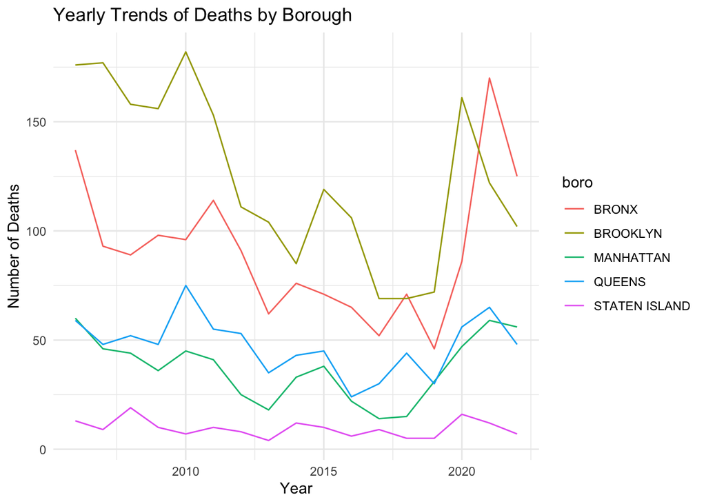

```r
ggplot(borough_trends, aes(x = Year, y = deaths, color = boro)) +
  geom_line() +
  labs(title = "Yearly Trends of Deaths by Borough",
       x = "Year",
       y = "Number of Deaths") +
  theme_minimal()
```

The results show that the boroughs all had some drops from 2010-2019. The largest drops were in the Bronx and Brooklyn. Given the drop from 2010 to 2019 I want to build a forecast model to see if how each borough will progress over the next few years.

## Forecast Model

We will build a forecast model to predict future deaths in each borough. To do this I have used the ARIMA model. First I will prepare the data by converting to a time series format. Then I will fit the model with auto.arima so it can automatically choose the best model. Next I will use the fitted model to forecast the future values. Finally I will plot the values. I will do this with each of the 5 boroughs.

#### Bronx

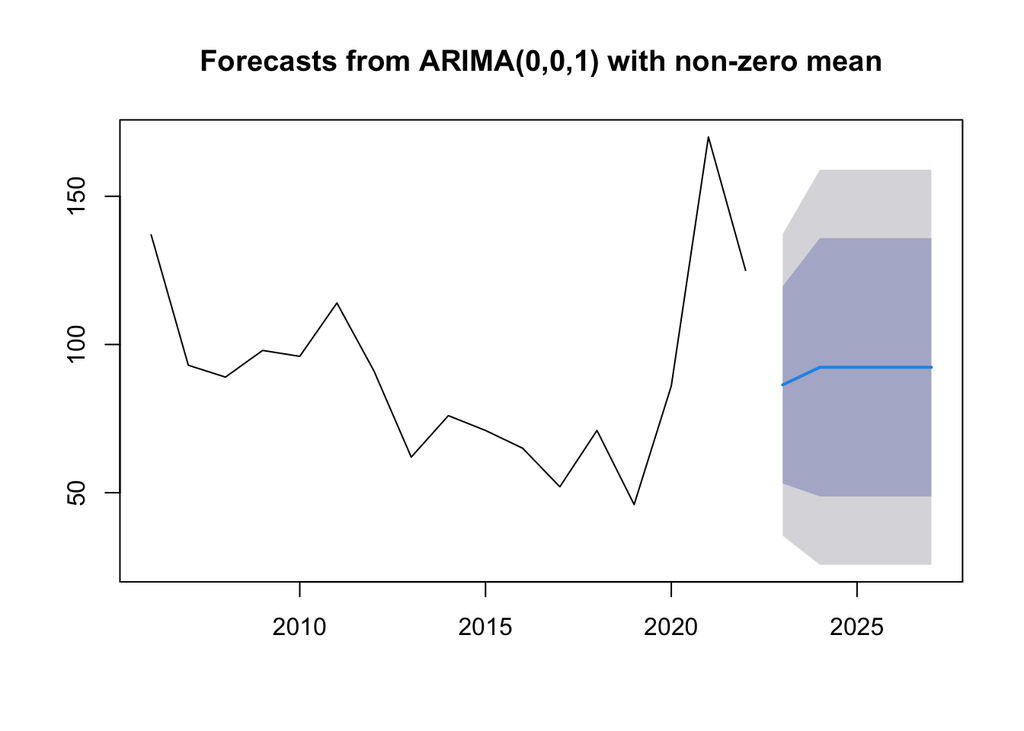

```r
bronx_ts <- ts(borough_trends$deaths[borough_trends$boro == "BRONX"], start = c(2006), frequency = 1)

bronx_arima <- auto.arima(bronx_ts)

bronx_forecast <- forecast(bronx_arima, h = 5)

plot(bronx_forecast)
```

```r
print(bronx_forecast)
```

```
##      Point Forecast    Lo 80    Hi 80    Lo 95    Hi 95
## 2023       86.38877 53.11531 119.6622 35.50140 137.2761
## 2024       92.31907 48.75442 135.8837 25.69268 158.9454
## 2025       92.31907 48.75442 135.8837 25.69268 158.9454
## 2026       92.31907 48.75442 135.8837 25.69268 158.9454
## 2027       92.31907 48.75442 135.8837 25.69268 158.9454
```

#### Brooklyn

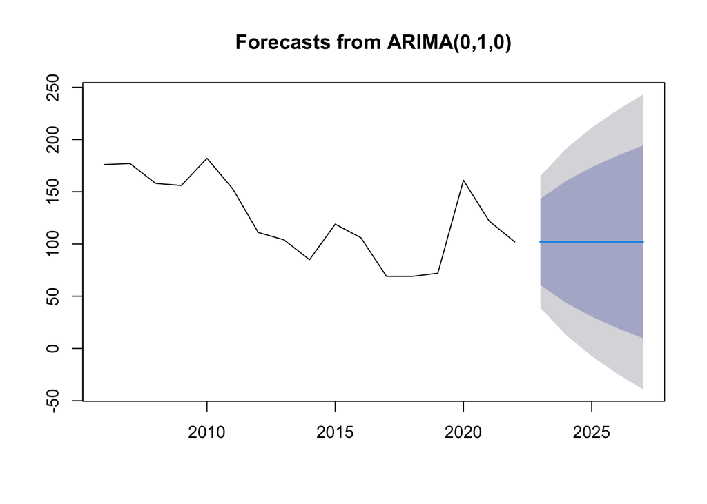

```r
brooklyn_ts <- ts(borough_trends$deaths[borough_trends$boro == "BROOKLYN"], start = c(2006), frequency = 1)

brooklyn_arima <- auto.arima(brooklyn_ts)

brooklyn_forecast <- forecast(brooklyn_arima, h = 5)

plot(brooklyn_forecast)
```

```r
print(brooklyn_forecast)
```

```
##      Point Forecast     Lo 80    Hi 80      Lo 95    Hi 95
## 2023            102 60.718383 143.2816  38.865214 165.1348
## 2024            102 43.618977 160.3810  12.713930 191.2861
## 2025            102 30.498141 173.5019  -7.352656 211.3527
## 2026            102 19.436765 184.5632 -24.269571 228.2696
## 2027            102  9.691497 194.3085 -39.173672 243.1737
```

#### Manhattan

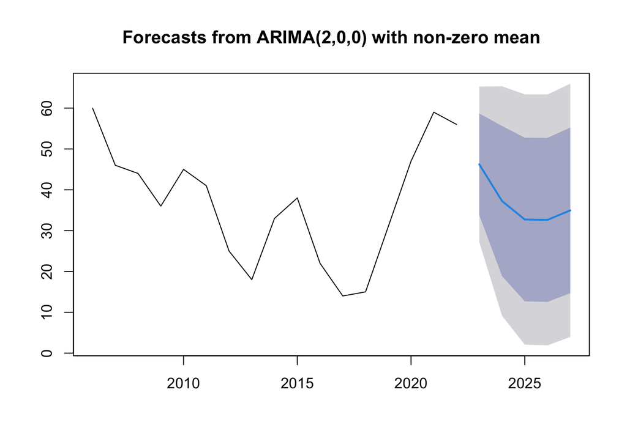

```r
manhattan_ts <- ts(borough_trends$deaths[borough_trends$boro == "MANHATTAN"], start = c(2006), frequency = 1)

manhattan_arima <- auto.arima(manhattan_ts)

manhattan_forecast <- forecast(manhattan_arima, h = 5)

plot(manhattan_forecast)
```

```r
print(manhattan_forecast)
```

```
##      Point Forecast    Lo 80    Hi 80     Lo 95    Hi 95
## 2023       46.23601 33.78790 58.68413 27.198264 65.27376
## 2024       37.24575 18.87387 55.61763  9.148381 65.34312
## 2025       32.72105 12.68537 52.75674  2.079120 63.36299
## 2026       32.62878 12.54183 52.71573  1.908445 63.34912
## 2027       34.95402 14.68264 55.22540  3.951620 65.95642
```

#### Queens

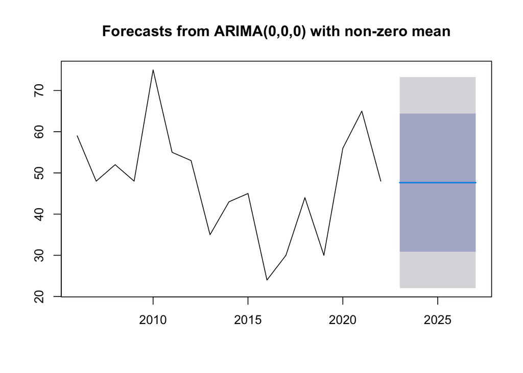

```r
queens_ts <- ts(borough_trends$deaths[borough_trends$boro == "QUEENS"], start = c(2006), frequency = 1)

queens_arima <- auto.arima(queens_ts)

queens_forecast <- forecast(queens_arima, h = 5)

plot(queens_forecast)
```

```r
print(queens_forecast)
```

```
##      Point Forecast    Lo 80    Hi 80    Lo 95    Hi 95
## 2023       47.64706 30.89508 64.39903 22.02712 73.26699
## 2024       47.64706 30.89508 64.39903 22.02712 73.26699
## 2025       47.64706 30.89508 64.39903 22.02712 73.26699
## 2026       47.64706 30.89508 64.39903 22.02712 73.26699
## 2027       47.64706 30.89508 64.39903 22.02712 73.26699
```

#### Staten Island

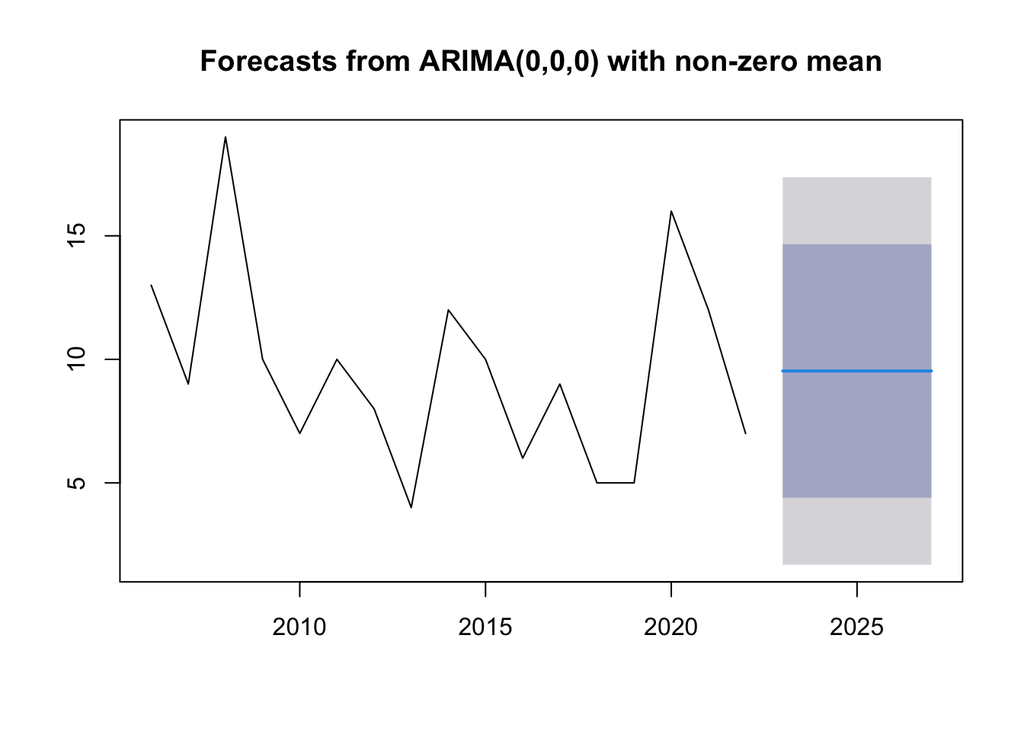

```r
staten_island_ts <- ts(borough_trends$deaths[borough_trends$boro == "STATEN ISLAND"], start = c(2006), frequency = 1)

staten_island_arima <- auto.arima(staten_island_ts)

staten_island_forecast <- forecast(staten_island_arima, h = 5)

plot(staten_island_forecast)
```

```r
print(staten_island_forecast)
```

```
##      Point Forecast   Lo 80    Hi 80    Lo 95    Hi 95
## 2023       9.529412 4.40085 14.65797 1.685954 17.37287
## 2024       9.529412 4.40085 14.65797 1.685954 17.37287
## 2025       9.529412 4.40085 14.65797 1.685954 17.37287
## 2026       9.529412 4.40085 14.65797 1.685954 17.37287
## 2027       9.529412 4.40085 14.65797 1.685954 17.37287
```

## Bias Identification

1. Data Collection Bias
   - Its important to note that if this data was collected by police reports it may have biases based on an officers perception.
2. Variable Bias
   - I removed 11 different columns that did not initially seem important to me. I wanted to reduce the amount of data I would have to make working with the data set more efficient. Others may had seen this data as valuable and kept it.
3. Missing data bias
   - Due to the columns containing a lot of empty or blank entries I ended up removing 3 more different columns. These were perp age group, perp sex, and perp race. These 3 columns could had been used to made some discoveries such as seeing if there was a correlation between perp demographics and victime demographic.